# R for Data Science Chapter 1: Data Visualisation

### 5 Numerical variables

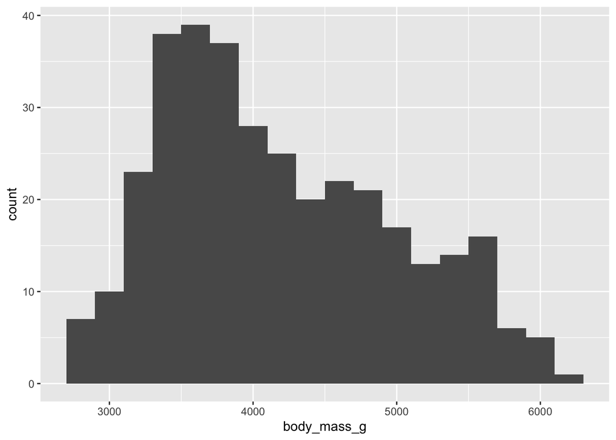

```r
ggplot(penguins, aes(x = body_mass_g)) +
  geom_histogram(binwidth = 200)
```

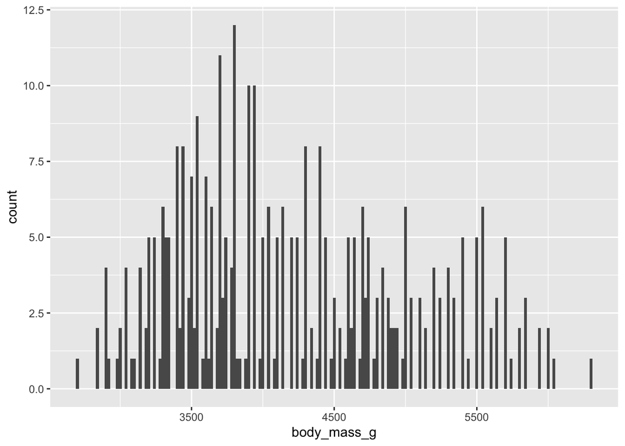

```r
ggplot(penguins, aes(x = body_mass_g)) +
  geom_histogram(binwidth = 20)
```

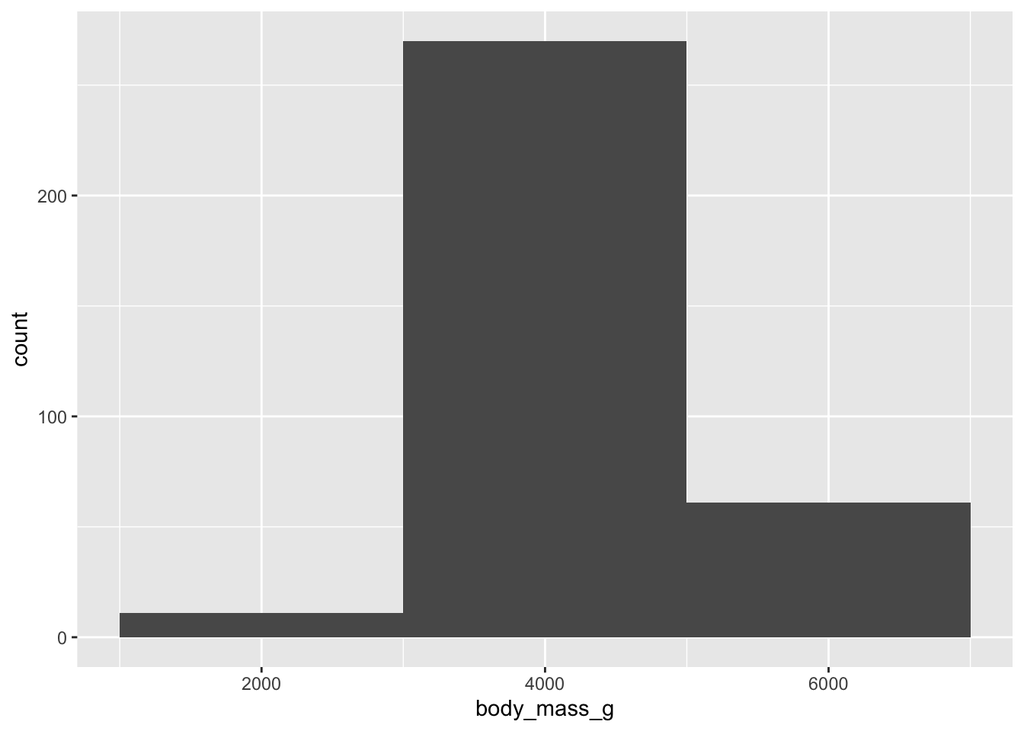

```r
ggplot(penguins, aes(x = body_mass_g)) +
  geom_histogram(binwidth = 2000)
```

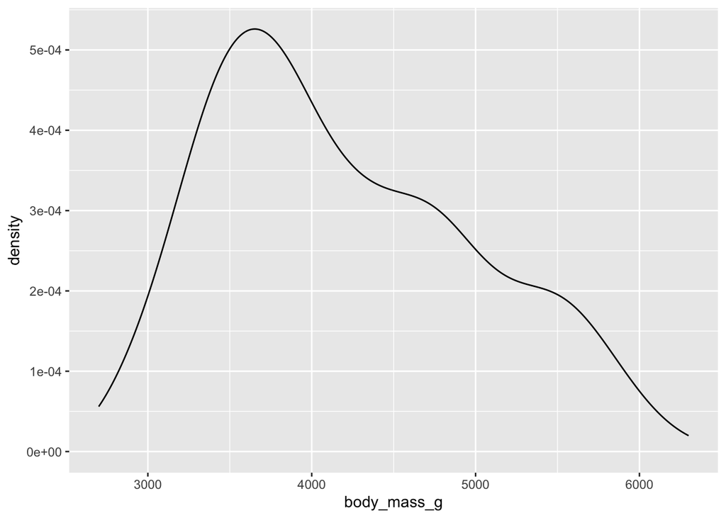

```r
ggplot(penguins, aes(x = body_mass_g)) +
  geom_density()
```

### 6 Exercises

#### 6.1 Make a bar plot of species of penguins, where you assign species to the y aesthetic. How is this plot different?

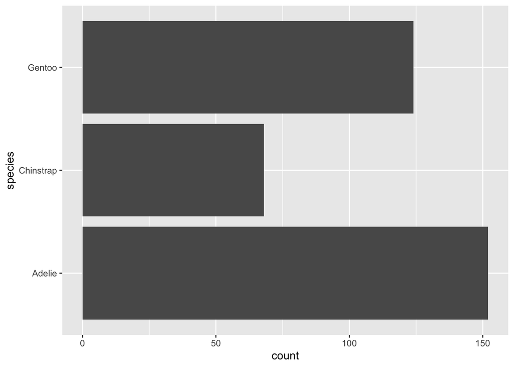

```r
ggplot(penguins, aes(y = species)) +
  geom_bar()
```

The plot is different as it is horizontal in nature compared to putting the Species on the x axis. It shows the same results but just in a different fashion.

#### 6.2 How are the following two plots different? Which aesthetic, color or fill, is more useful for changing the color of bars?

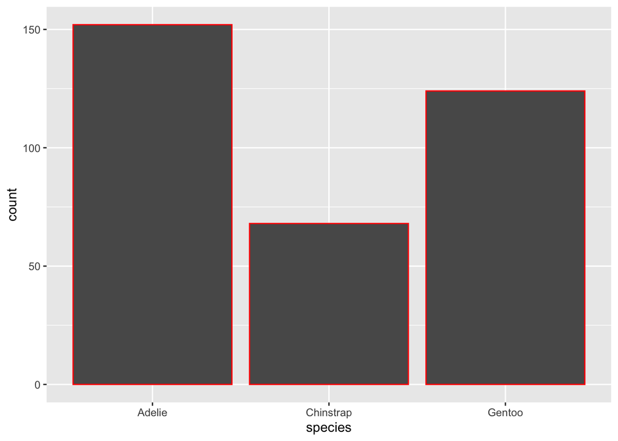

```r
ggplot(penguins, aes(x = species)) +
  geom_bar(color = "red")
```

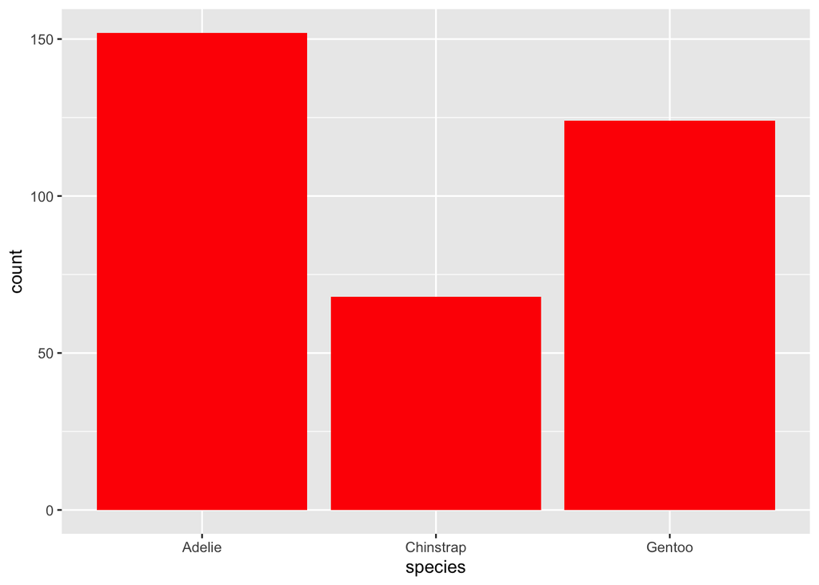

```r
ggplot(penguins, aes(x = species)) +
  geom_bar(fill = "red")
```

The first bar uses the color function to color the perimeter of the bar chart while the fill function fills the bar with a specified color. The fill option would be more useful as this can be used later to outline the differences between variables in colour.

### 7 Numerical and categorical variables

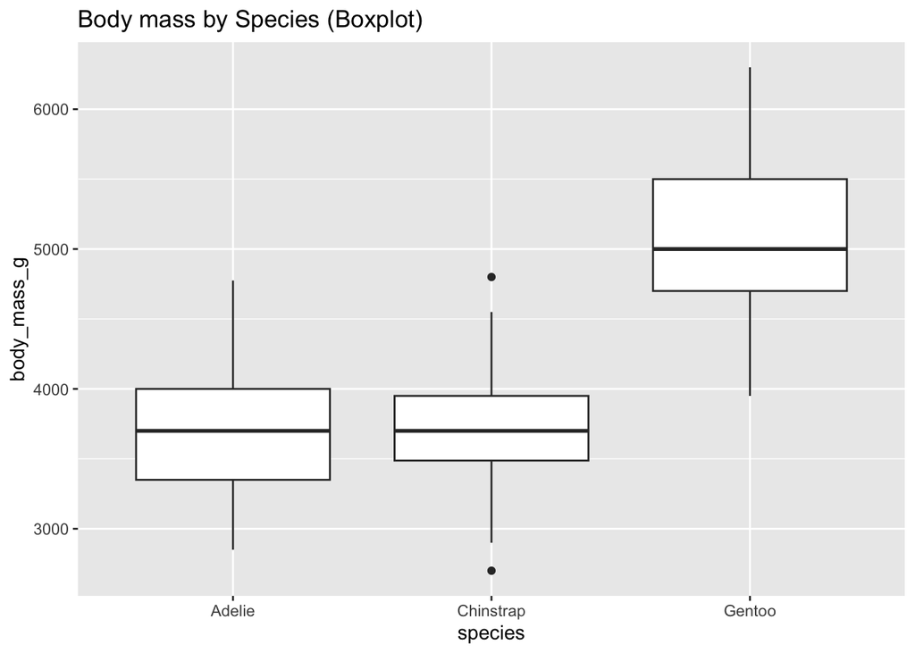

```r
ggplot(penguins, aes(x = species, y = body_mass_g)) +
  geom_boxplot() +
  labs(title = "Body mass by Species (Boxplot)")
```

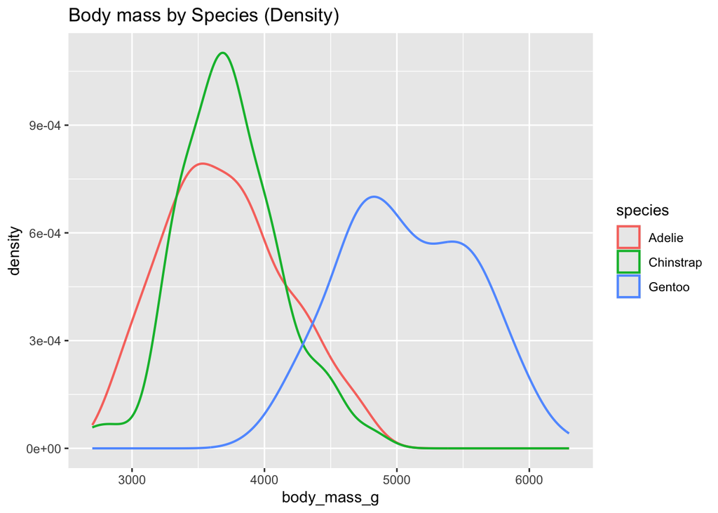

```r
ggplot(penguins, aes(x = body_mass_g, color = species)) +
  geom_density(linewidth = 0.75) +
  labs(title = "Body mass by Species (Density)")
```

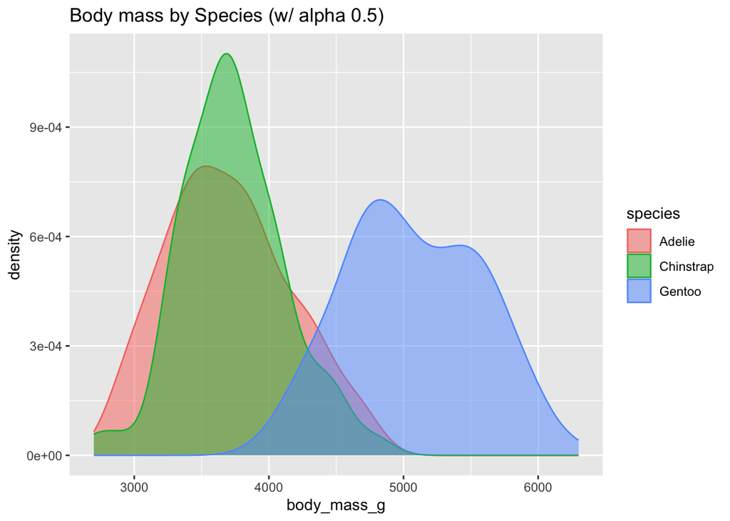

```r
ggplot(penguins, aes(x = body_mass_g, color = species, fill = species)) +
  geom_density(alpha = 0.5) +
  labs(title = "Body mass by Species (w/ alpha 0.5)")
```